# Sonu Flipkart Product Badminton

```python
import numpy as np
import pandas as pd

PATH = r"C:\Users\Sonu Vikas\Desktop\Internship 2024\Flipkart Product\reviews_badminton\data.csv"

df = pd.read_csv(PATH)
dataFrame=df
```

```python
df
```

|  | Reviewer Name | Review Title | Place of Review | Up Votes | Down Votes | Month | Review text | Ratings |
| --- | --- | --- | --- | --- | --- | --- | --- | --- |
| 0 | Kamal Suresh | Nice product | Certified Buyer, Chirakkal | 889.0 | 64.0 | Feb 2021 | Nice product, good quality, but price is now r... | 4 |
| 1 | Flipkart Customer | Don't waste your money | Certified Buyer, Hyderabad | 109.0 | 6.0 | Feb 2021 | They didn't supplied Yonex Mavis 350. Outside ... | 1 |
| 2 | A. S. Raja Srinivasan | Did not meet expectations | Certified Buyer, Dharmapuri | 42.0 | 3.0 | Apr 2021 | Worst product. Damaged shuttlecocks packed in ... | 1 |
| 3 | Suresh Narayanasamy | Fair | Certified Buyer, Chennai | 25.0 | 1.0 | NaN | Quite O. K. , but nowadays the quality of the... | 3 |
| 4 | ASHIK P A | Over priced | NaN | 147.0 | 24.0 | Apr 2016 | Over pricedJust â?¹620 ..from retailer.I didn'... | 1 |
| ... | ... | ... | ... | ... | ... | ... | ... | ... |
| 8513 | NaN | NaN | NaN | NaN | NaN | NaN | NaN | 5 |
| 8514 | NaN | NaN | NaN | NaN | NaN | NaN | NaN | 2 |
| 8515 | NaN | NaN | NaN | NaN | NaN | NaN | NaN | 4 |
| 8516 | NaN | NaN | NaN | NaN | NaN | NaN | NaN | 1 |
| 8517 | NaN | NaN | NaN | NaN | NaN | NaN | NaN | 4 |

8518 rows × 8 columns

```python
df.head()
```

|  | Reviewer Name | Review Title | Place of Review | Up Votes | Down Votes | Month | Review text | Ratings |
| --- | --- | --- | --- | --- | --- | --- | --- | --- |
| 0 | Kamal Suresh | Nice product | Certified Buyer, Chirakkal | 889.0 | 64.0 | Feb 2021 | Nice product, good quality, but price is now r... | 4 |
| 1 | Flipkart Customer | Don't waste your money | Certified Buyer, Hyderabad | 109.0 | 6.0 | Feb 2021 | They didn't supplied Yonex Mavis 350. Outside ... | 1 |
| 2 | A. S. Raja Srinivasan | Did not meet expectations | Certified Buyer, Dharmapuri | 42.0 | 3.0 | Apr 2021 | Worst product. Damaged shuttlecocks packed in ... | 1 |
| 3 | Suresh Narayanasamy | Fair | Certified Buyer, Chennai | 25.0 | 1.0 | NaN | Quite O. K. , but nowadays the quality of the... | 3 |
| 4 | ASHIK P A | Over priced | NaN | 147.0 | 24.0 | Apr 2016 | Over pricedJust â?¹620 ..from retailer.I didn'... | 1 |

```python
df.tail()
```

|  | Reviewer Name | Review Title | Place of Review | Up Votes | Down Votes | Month | Review text | Ratings |
| --- | --- | --- | --- | --- | --- | --- | --- | --- |
| 8513 | NaN | NaN | NaN | NaN | NaN | NaN | NaN | 5 |
| 8514 | NaN | NaN | NaN | NaN | NaN | NaN | NaN | 2 |
| 8515 | NaN | NaN | NaN | NaN | NaN | NaN | NaN | 4 |
| 8516 | NaN | NaN | NaN | NaN | NaN | NaN | NaN | 1 |
| 8517 | NaN | NaN | NaN | NaN | NaN | NaN | NaN | 4 |

```python
df.shape
```

```
(8518, 8)
```

```python
df.columns
```

```
Index(['Reviewer Name', 'Review Title', 'Place of Review', 'Up Votes',
       'Down Votes', 'Month', 'Review text', 'Ratings'],
      dtype='object')
```

```python
df.describe
```

```
<bound method NDFrame.describe of                Reviewer Name               Review Title  \
0               Kamal Suresh               Nice product
1          Flipkart Customer     Don't waste your money
2     A. S. Raja Srinivasan   Did not meet expectations
3        Suresh Narayanasamy                       Fair
4                  ASHIK P A                Over priced
...                      ...                        ...
8513                     NaN                        NaN
8514                     NaN                        NaN
8515                     NaN                        NaN
8516                     NaN                        NaN
8517                     NaN                        NaN

                  Place of Review  Up Votes  Down Votes     Month  \
0      Certified Buyer, Chirakkal     889.0        64.0  Feb 2021
```

[output cut: 25 more lines]

```python
#Renaming the Columns
df.columns = df.columns.str.strip()

df.columns
```

```
Index(['Reviewer Name', 'Review Title', 'Place of Review', 'Up Votes',
       'Down Votes', 'Month', 'Review text', 'Ratings'],
      dtype='object')
```

```python
df.info()
```

```
<class 'pandas.core.frame.DataFrame'>
RangeIndex: 8518 entries, 0 to 8517
Data columns (total 8 columns):
 #   Column           Non-Null Count  Dtype
---  ------           --------------  -----
 0   Reviewer Name    8508 non-null   object
 1   Review Title     8508 non-null   object
 2   Place of Review  8468 non-null   object
 3   Up Votes         8508 non-null   float64
 4   Down Votes       8508 non-null   float64
 5   Month            8053 non-null   object
 6   Review text      8510 non-null   object
 7   Ratings          8518 non-null   int64
dtypes: float64(2), int64(1), object(5)
memory usage: 532.5+ KB
```

```python
# Check for missing values
print(df.isnull().sum())
```

```
Reviewer Name       10
Review Title        10
Place of Review     50
Up Votes            10
Down Votes          10
Month              465
Review text          8
Ratings              0
dtype: int64
```

```python
df.describe()
```

|  | Up Votes | Down Votes | Ratings |
| --- | --- | --- | --- |
| count | 8508.000000 | 8508.000000 | 8518.000000 |
| mean | 0.391396 | 0.121768 | 4.181028 |
| std | 11.613909 | 3.248022 | 1.262200 |
| min | 0.000000 | 0.000000 | 1.000000 |
| 25% | 0.000000 | 0.000000 | 4.000000 |
| 50% | 0.000000 | 0.000000 | 5.000000 |
| 75% | 0.000000 | 0.000000 | 5.000000 |
| max | 889.000000 | 219.000000 | 5.000000 |

# Handling missing / Null values

```python
df.fillna({'Reviewer Name': 'Anonymous',
           'Review Title': 'No Title',
           'Place of Review': 'Unknown',
           'Up Votes': df['Up Votes'].median(),
           'Down Votes': df['Down Votes'].median(),
           'Month': 'Unknown'},
          inplace=True)
```

```python
# Check for missing values
print(df.isnull().sum())
```

```
Reviewer Name      0
Review Title       0
Place of Review    0
Up Votes           0
Down Votes         0
Month              0
Review text        8
Ratings            0
dtype: int64
```

```python
df.tail()
```

|  | Reviewer Name | Review Title | Place of Review | Up Votes | Down Votes | Month | Review text | Ratings |
| --- | --- | --- | --- | --- | --- | --- | --- | --- |
| 8513 | Anonymous | No Title | Unknown | 0.0 | 0.0 | Unknown | NaN | 5 |
| 8514 | Anonymous | No Title | Unknown | 0.0 | 0.0 | Unknown | NaN | 2 |
| 8515 | Anonymous | No Title | Unknown | 0.0 | 0.0 | Unknown | NaN | 4 |
| 8516 | Anonymous | No Title | Unknown | 0.0 | 0.0 | Unknown | NaN | 1 |
| 8517 | Anonymous | No Title | Unknown | 0.0 | 0.0 | Unknown | NaN | 4 |

```python
# Convert 'Month' column to datetime data type
df['Month'] = pd.to_datetime(df['Month'], errors='coerce')
```

```python
# Convert 'Up Votes' and 'Down Votes' columns to integer data type
df['Up Votes'] = df['Up Votes'].astype(int)
df['Down Votes'] = df['Down Votes'].astype(int)
```

```python
# Remove spaces from column names
df.columns = df.columns.str.replace(' ', '_')

# Check the updated data types and column names
print(df.dtypes)
print(df.columns)
```

```
Reviewer_Name              object
Review_Title               object
Place_of_Review            object
Up_Votes                    int32
Down_Votes                  int32
Month              datetime64[ns]
Review_text                object
Ratings                     int64
dtype: object
Index(['Reviewer_Name', 'Review_Title', 'Place_of_Review', 'Up_Votes',
       'Down_Votes', 'Month', 'Review_text', 'Ratings'],
      dtype='object')
```

# Summary Statistics

```python
print(df.describe())
```

```
          Up_Votes   Down_Votes      Ratings
count  8518.000000  8518.000000  8518.000000
mean      0.390937     0.121625     4.181028
std      11.607097     3.246117     1.262200
min       0.000000     0.000000     1.000000
25%       0.000000     0.000000     4.000000
50%       0.000000     0.000000     5.000000
75%       0.000000     0.000000     5.000000
max     889.000000   219.000000     5.000000
```

```python
df.describe()
```

[output not shown]

# Interpretation:

The majority of reviews have zero up votes and down votes, as indicated by the 25th, 50th, and 75th percentiles. However, there are some outliers with a maximum of 889 up votes and 219 down votes. The ratings range from 1 to 5, with a mean rating of approximately 4.18, indicating generally positive sentiment among reviewers. These statistics provide valuable insights into the distribution and variability of up votes, down votes, and ratings among the reviews. They can guide further analysis and decision-making processes related to customer satisfaction and engagement with the product.

```python
# Distribution of ratings
print(df['Ratings'].value_counts())
```

```
5    5080
4    1746
1     769
3     615
2     308
Name: Ratings, dtype: int64
```

# Data Vizualization

## Distribution Analysis

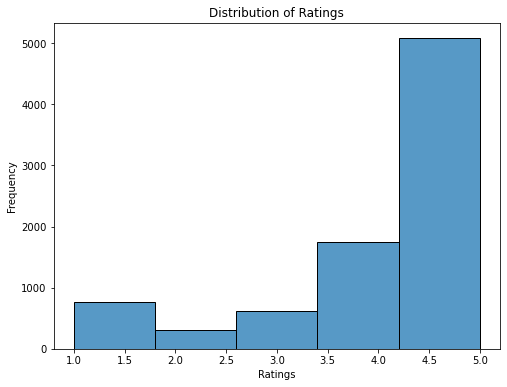

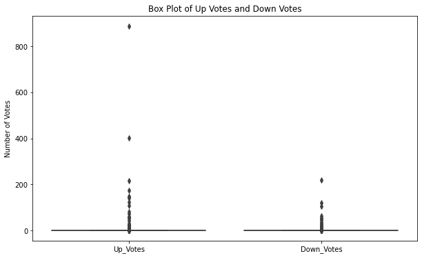

```python
import matplotlib.pyplot as plt
import seaborn as sns

# Histogram of Ratings
plt.figure(figsize=(8, 6))
sns.histplot(df['Ratings'], bins=5, kde=False)
plt.title('Distribution of Ratings')
plt.xlabel('Ratings')
plt.ylabel('Frequency')
plt.show()

# Box plot of Up Votes and Down Votes
plt.figure(figsize=(10, 6))
sns.boxplot(data=df[['Up_Votes', 'Down_Votes']])
plt.title('Box Plot of Up Votes and Down Votes')
plt.ylabel('Number of Votes')
plt.show()
```

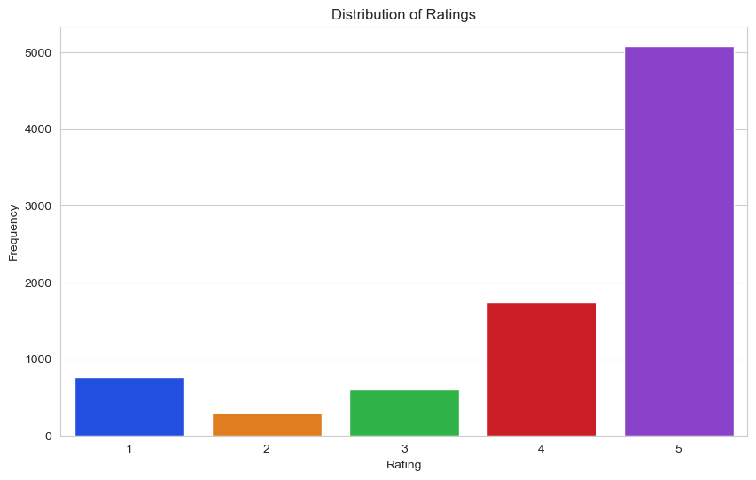

```python
import pandas as pd
import matplotlib.pyplot as plt
import seaborn as sns

# Assuming your dataframe is named 'df'

# Drop rows with NaN values in 'Ratings' column
df.dropna(subset=['Ratings'], inplace=True)

# Convert 'Ratings' column to integer type
df['Ratings'] = df['Ratings'].astype(int)

# Set seaborn style
sns.set_style("whitegrid")

# Define a color palette
palette = sns.color_palette("bright")

# Distribution analysis using bar chart with different colors
plt.figure(figsize=(10, 6))
sns.countplot(data=df, x='Ratings', palette=palette)
plt.xlabel('Rating')
plt.ylabel('Frequency')
plt.title('Distribution of Ratings')
plt.xticks(rotation=0)
plt.show()
```

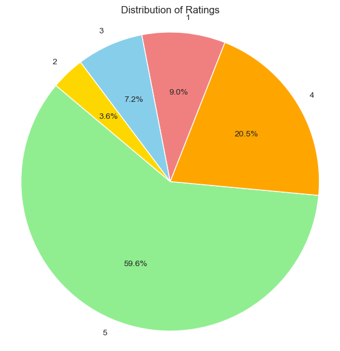

```python
import pandas as pd
import matplotlib.pyplot as plt

# Assuming your dataframe is named 'df'

# Drop rows with NaN values in 'Ratings' column
df.dropna(subset=['Ratings'], inplace=True)

# Convert 'Ratings' column to integer type
df['Ratings'] = df['Ratings'].astype(int)

# Distribution analysis using pie chart
plt.figure(figsize=(7, 7))
rating_counts = df['Ratings'].value_counts()
plt.pie(rating_counts, labels=rating_counts.index, autopct='%1.1f%%', startangle=140, colors=['lightgreen', 'orange', 'lightcoral', 'skyblue', 'gold'])
plt.title('Distribution of Ratings')
plt.axis('equal')
plt.show()
```

# Analyzing the Relationship between Ratings and Engagement Metrics:

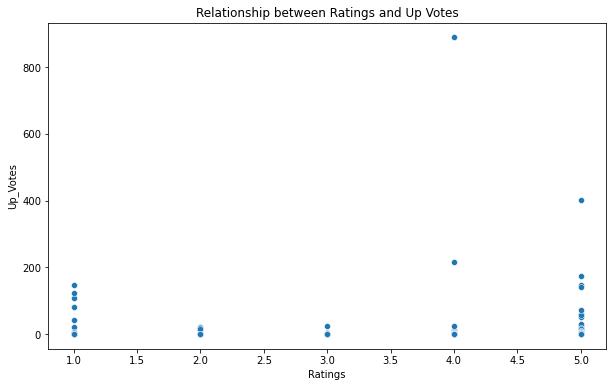

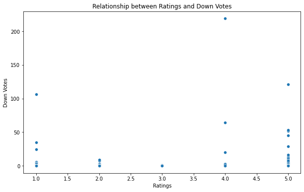

```python
import seaborn as sns

# Scatter plot to visualize the relationship between Ratings and Up Votes
plt.figure(figsize=(10, 6))
sns.scatterplot(data=df, x='Ratings', y='Up_Votes')
plt.title('Relationship between Ratings and Up Votes')
plt.xlabel('Ratings')
plt.ylabel('Up_Votes')
plt.show()

# Scatter plot to visualize the relationship between Ratings and Down Votes
plt.figure(figsize=(10, 6))
sns.scatterplot(data=df, x='Ratings', y='Down_Votes')
plt.title('Relationship between Ratings and Down Votes')
plt.xlabel('Ratings')
plt.ylabel('Down Votes')
plt.show()
```

# Categorical Variable analysis

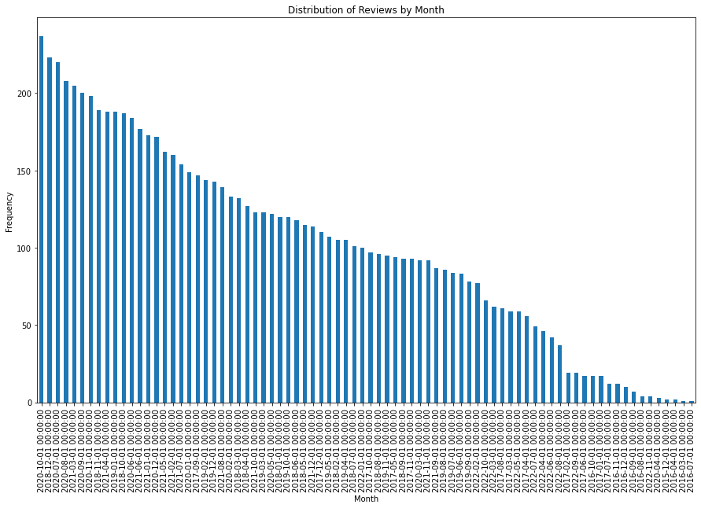

```python
plt.figure(figsize=(15, 9))
df['Month'].value_counts().plot(kind='bar')
plt.xlabel('Month')
plt.ylabel('Frequency')
plt.title('Distribution of Reviews by Month')
plt.xticks(rotation=90)
plt.show()
```

[figure not shown]

```python
import matplotlib.pyplot as plt
import seaborn as sns  # Import seaborn for color palettes

# Assuming df['Month'] contains the months as strings

plt.figure(figsize=(15, 9))

# Using seaborn's color palette 'muted'
sns.countplot(x='Month', data=df, palette='bright')

plt.xlabel('Month')
plt.ylabel('Frequency')
plt.title('Distribution of Reviews by Month')
plt.xticks(rotation=90)
plt.show()
```

# Sentiment Analysis on text data

```python
# Perform sentiment analysis using TextBlob
from textblob import TextBlob

def get_sentiment(text):
    analysis = TextBlob(text)
    if analysis.sentiment.polarity > 0:
        return 'Positive'
    elif analysis.sentiment.polarity < 0:
        return 'Negative'
    else:
        return 'Neutral'

# Apply sentiment analysis to the 'Review Text' column
df['Sentiment'] = df['Review_text'].apply(get_sentiment)

# Visualize sentiment distribution
plt.figure(figsize=(8, 6))
sns.countplot(x='Sentiment', data=df)
plt.title('Sentiment Distribution')
plt.xlabel('Sentiment')
plt.ylabel('Count')
plt.show()
```

[output not shown]

```python
import nltk
from nltk.sentiment.vader import SentimentIntensityAnalyzer

# Download NLTK resources
nltk.download('vader_lexicon')

# Initialize the Sentiment Intensity Analyzer
sid = SentimentIntensityAnalyzer()
```

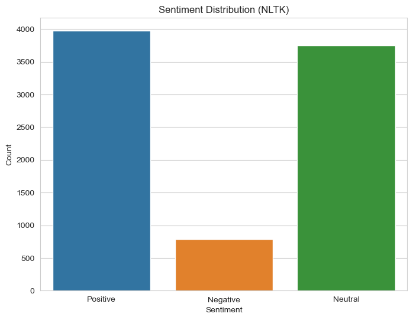

```python
import pandas as pd
import matplotlib.pyplot as plt
import seaborn as sns
from nltk.sentiment.vader import SentimentIntensityAnalyzer

# Assuming your dataframe is named 'df'

# Drop rows with NaN values in 'Review text' column
df.dropna(subset=['Review text'], inplace=True)

# Initialize NLTK's SentimentIntensityAnalyzer
sia = SentimentIntensityAnalyzer()

# Define a function to get sentiment using NLTK
def get_sentiment_nltk(text):
    sentiment_score = sia.polarity_scores(text)['compound']
    if sentiment_score > 0.05:
        return 'Positive'
    elif sentiment_score < -0.05:
        return 'Negative'
    else:
        return 'Neutral'

# Apply sentiment analysis to the 'Review text' column
df['Sentiment_NLTK'] = df['Review text'].apply(get_sentiment_nltk)

# Visualize sentiment distribution
plt.figure(figsize=(8, 6))
sns.countplot(x='Sentiment_NLTK', data=df)
plt.title('Sentiment Distribution (NLTK)')
plt.xlabel('Sentiment')
plt.ylabel('Count')
plt.show()
```

# Text Data

```python
# Distribution on target variable looks non-uniform
df['Sentiment_NLTK'].value_counts(normalize=True)
```

```
Positive    0.466745
Neutral     0.440776
Negative    0.092479
Name: Sentiment_NLTK, dtype: float64
```

```python
# removing the data where we don't want, i.e.'netural'.
df = df[df.Sentiment_NLTK != "Neutral"]

df.shape
```

```
(4759, 9)
```

```python
df['Sentiment_NLTK'].value_counts(normalize=True)
```

```
Positive    0.834629
Negative    0.165371
Name: Sentiment_NLTK, dtype: float64
```

# Sentiment_NLTK for sentiment analysis

```python
# Define a dictionary to map sentiment categories to numerical values
sentiment_mapping = {'Positive': 1, 'Negative': 0}

# Map sentiment categories to numerical values in the 'Sentiment_NLTK' column
df['Sentiment_NLTK_numeric'] = df['Sentiment_NLTK'].map(sentiment_mapping)

# Display the updated DataFrame
print(df[['Sentiment_NLTK', 'Sentiment_NLTK_numeric']].head())
```

```
  Sentiment_NLTK  Sentiment_NLTK_numeric
0       Positive                       1
1       Negative                       0
2       Negative                       0
3       Positive                       1
4       Positive                       1
```

[output not shown]

```python
df.loc[0, 'Review text']
```

```
'Nice product, good quality, but price is now rising which is a bad sign. 800-850 was an affordable price, especially when we play everyday. So kindly help us out in terms of the price. Thank You.READ MORE'
```

```python
# Let us take only the two columns we need
df = df[["Review text", "Sentiment_NLTK_numeric"]]
df.shape
```

```
(4759, 2)
```